# Automatiza la publicación de tus reportes

## Tipos de steps (pasos)

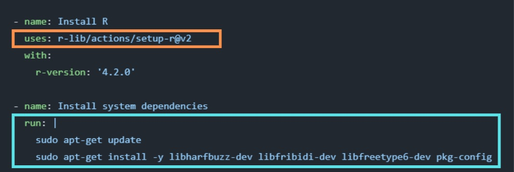

**uses** utiliza una acción ya existente, empaquetada por GitHub o la comunidad

## Tipos de steps (pasos)

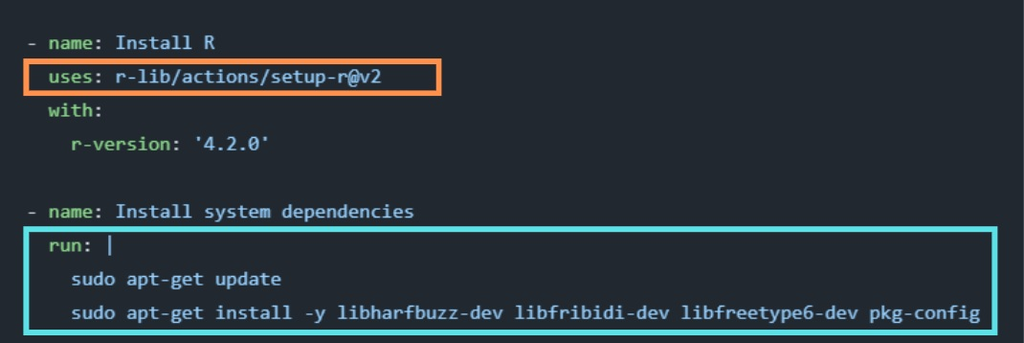

**run** ejecuta comandos directamente en la terminal del runner

## Tipos de steps (pasos)

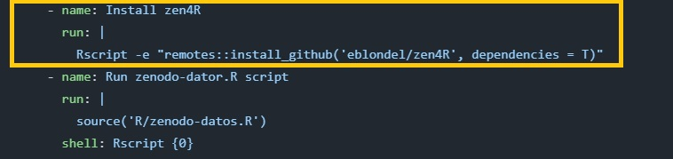

- Se puede ejecutar código en la terminal (shell) de la maquina virtual (para ubuntu, es bash)

## Tipos de steps (pasos)

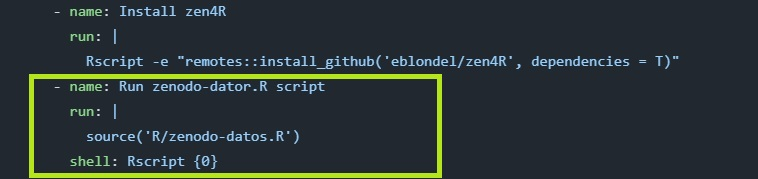

- Se puede ejecutar código indicando una terminal particular, en este caso la de R.

## Tipos de steps (pasos)

Este paso usa una acción pre empaquetada para publicar un proyecto de Quarto.

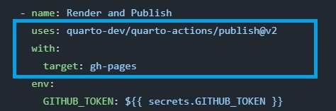

**with:**

- Los argumentos que la acción necesita para funcionar.
- **target:** gh-pages/netlify/connect

## Tipos de steps (pasos)

**env:**

- Variables de entorno.
- GITHUB_TOKEN

## GITHUB_TOKEN

**Token de autorización** que GitHub genera automáticamente para cada ejecución de un workflow de GitHub Actions.

- Identifica al workflow y le permite interactuar con GitHub
- Solo existe mientras dura la ejecución
- Tiene permisos controlables

## Secretos del repositorio

- **secrets** hace referencia a un espacio seguro donde GitHub guarda valores sensibles (claves, tokens, constraseñas) encriptados.

## Secretos del repositorio

- **GITHUB_TOKEN** es el nombre de uno de esos valores.

[figure not shown]

## Tipos de eventos que disparan un workflow (Triggers)

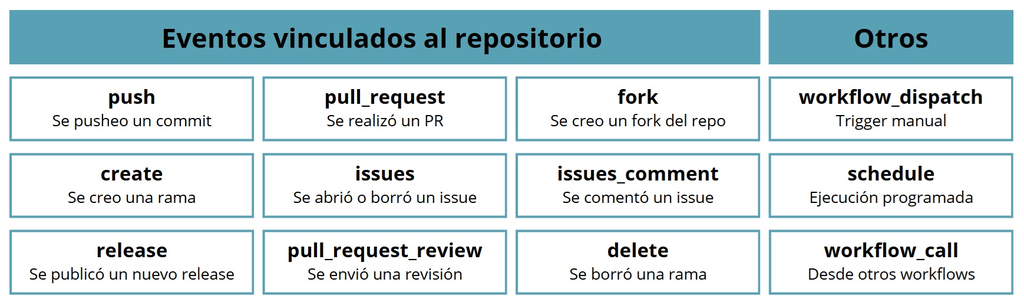

# Actualización automática y publicación en GitHub Pages

**Trabajamos en el repositorio**

## Repaso de la práctica

- Creamos un fork del repositorio censo-meriendas
- Creamos el archivo .github/workflows/_publish.yml
- Creamos la rama “gh-pages” y revisamos el setup en settings/pages
- Modificamos los triggers para:
  - Actualizar tras cada push
  - Actualizar periódicamente
- Revisamos el log de un workflow

# Mini-evaluación 2

## Mini-evaluación 2:

### En qué parte del YAML se indica cuáles serán los disparadores del workflow?

👍 jobs:

😮 steps:

👏 on:

## Mini-evaluación 2:

### ¿De qué manera se puede ejecutar código de R dentro de una GHA?

👍 Dentro de un R script (ejemplo.R) via terminal de la VM

😮 Dentro de un R script (ejemplo.R) via terminal de R

🎉 Como un comando R aislado via `Rscript -e` (install.packages())

👏 Todas las opciones son correctas

# Buenas prácticas

## Buenas prácticas

- Separar el “build”, las pruebas (“test”) y el “deploy” en jobs independientes.
- Paralelizar jobs cuando sea posible.
- Reutilizar acciones de terceros (third-party actions)
- Instalar versiones específicas de las herramientas
- Aplicar el principio de menor privilegio.
- **Gestionar claves de API y contraseñas como variables de entorno usando GitHub Secrets.**

## Secretos del repositorio

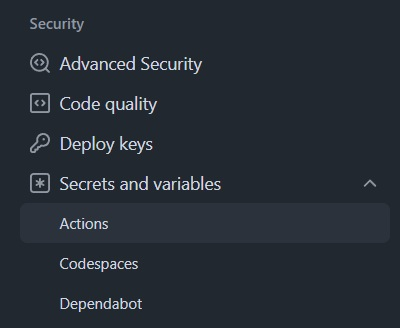

- Permiten acceder a credenciales o información sensible sin escribirlo directamente en el código.
- Todo lo que almacenamos aquí queda cifrado y nunca se muestra en texto plano.

## Secretos del repositorio

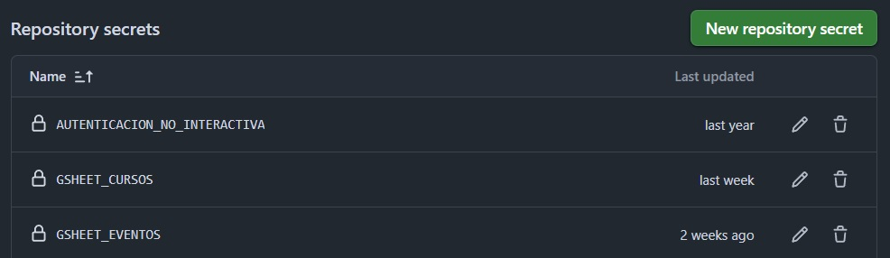

- Cada secreto tiene un **nombre** y un **valor oculto**.
- Usamos el nombre para invocar el valor desde GitHub Actions.

## Secretos del repositorio

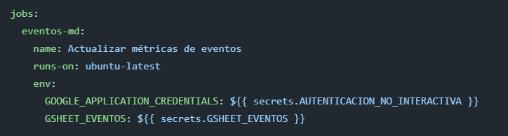

Con **env** creamos variables de entorno dentro del **job**, cuyo valor proviene de los secretos del repositorio.

## Secretos del repositorio

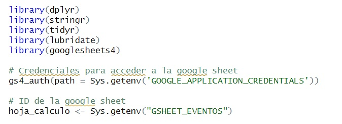

En **R**, las variables de entorno se leen con **Sys.getenv()**.

## Temas cubiertos por el taller

[figure not shown]

# **¡Muchas gracias por compartir este taller con nosotras!**

Por favor, dejanos una pequeña reseña aquí 👉 [**http://tiny.cc/quarto-GHA**](http://tiny.cc/quarto-GHA)

# Preguntas?

Contactanos! **jesica.formoso@gmail.com**| **mcnanton@gmail.com**